# 11.2 Universal approximators

You can toggle the code on and off in this presentation via the button below.

```python
from IPython.display import HTML

HTML('''<script>
code_show=true;
function code_toggle() {
 if (code_show){
 $('div.input').hide();
 } else {
 $('div.input').show();
 }
 code_show = !code_show
}
$( document ).ready(code_toggle);
</script>
<form action="javascript:code_toggle()"><input type="submit" value="Click here to toggle on/off the raw code."></form>''')
```

## Perfect data

A *perfect* dataset for regression or two-class classification has two important (albeit, unrealistic) characteristics:

- It is completely noiseless
- It is infinitely large

When we have unfettered access to perfect data, perfect features can be *learned* automatically by combining elements from a set of basic feature transformations, known as *universal approximators*, the most popular of which include *fixed-shape approximators*, *neural networks*, and *trees*.

[figure not shown]

(top left) A realistic linear **regression** dataset. (top middle) The noiseless version. (top right) The perfect version of the same data. (bottom left) A realistic nonlinear regression dataset. (bottom middle) The noiseless version. (bottom right) The perfect version, that is noiseless and infinitely large.

[figure not shown]

(top left) A realistic linear **two-class classification dataset**. (top middle) The noiseless version. (top right) The perfect version of the same data. (bottom left) A realistic nonlinear two-class classification dataset. (bottom middle) The noiseless version. (bottom right) The perfect version, that is noiseless and infinitely large.

- A perfect regression or two-class classification dataset is a continuous (or piece-wise continuous) function with unknown equation.
- Because of this we will refer to our perfect data using the function notation $y\left(\mathbf{x}\right)$, meaning that the data pair defined at input $\mathbf{x}$ can be written as either $\left(\mathbf{x},y\left(\mathbf{x}\right)\right)$ or likewise $\left(\mathbf{x},y\right)$.
- It is important to bear in mind that the function notation $y\left(\mathbf{x}\right)$ does not imply that we have knowledge of a closed form *formula* relating the input/output pairs of a perfect dataset, we do not!

## The spanning set analogy for universal approximation

### Linear combinations of vectors

- Assume we have a set of $B$ vectors $\left\{\mathbf{f}_1,\,\mathbf{f}_2,\,\ldots,\,\mathbf{f}_B\right\}$, each having dimension $N$.
- We call this a *spanning* set of vectors.
- Given a particular set of weights $w_1$ through $w_B$, the linear combination below defines a new $N$ dimensional vector $\mathbf{y}$

\begin{equation} \mathbf{f}_1w_1 + \mathbf{f}_2w_2 + \cdots + \mathbf{f}_Bw_B = \mathbf{y} \label{equation:linear-combination-vectors} \end{equation}

### Linear combinations of functions

Similarly, given a spanning set of $B$ nonlinear functions $\left\{f_1\left(\mathbf{x}\right),\,f_2\left(\mathbf{x}\right),\,\ldots,\,f_B\left(\mathbf{x}\right)\right\}$ (where the input $\mathbf{x}$ is $N$ dimensional and output is scalar) and a corresponding set of weights, the linear combination below defines a new function $y\left(\mathbf{x}\right)$

\begin{equation} w_0 + f_1\left(\mathbf{x}\right){w}_{1} + f_2\left(\mathbf{x}\right){w}_{2} + \cdots + f_B\left(\mathbf{x}\right)w_B = y\left(\mathbf{x}\right) \label{equation:linear-combination-functions} \end{equation}

[figure not shown]

A particular linear combination of three vectors (top) and three functions (bottom).

### Capacity of spanning sets

#### Vector approximation problem

- Computing the vector $\mathbf{y}$ in $\mathbf{f}_1w_1 + \mathbf{f}_2w_2 + \cdots + \mathbf{f}_Bw_B \approx \mathbf{y}$, for a *given* set of weights $w_1$ through $w_B$, is a trivial affair.
- The inverse problem, i.e., finding the weights given $\mathbf{y}$, is slightly more challenging.
- Stated algebraically, we want to find the weights $w_1$ through $w_B$ such that the following holds as well as possible.

\begin{equation} \mathbf{f}_1w_1 + \mathbf{f}_2w_2 + \cdots + \mathbf{f}_Bw_B \approx \mathbf{y} \label{equation:chap-11-vector-based-approximation} \end{equation}

How well the *vector approximation* $\mathbf{f}_1w_1 + \mathbf{f}_2w_2 + \cdots + \mathbf{f}_Bw_B \approx \mathbf{y}$ holds depends on three crucial and interrelated factors:

1. The diversity (i.e., linear independence) of the spanning vectors
2. The number $B$ of them used (in general the larger we make $B$ the better)
3. How well we tune the weights $w_1$ through $w_B$ via minimization of an appropriate cost
- Factors (1) and (2) determine a spanning set's *rank* or *capacity*, that is a measure for the range of vectors $\mathbf{y}$ we can possibly represent with such a spanning set.
- A spanning set with a *low capacity*, that is one consisting of a non-diverse and/or a small number of spanning vectors can approximate only a tiny fraction of those present in the entire vector space.
- A spanning set with a *high capacity* can represent a broader swath of the space.

#### Function approximation problem

We can try to find the weights $w_1$ through $w_B$, for a given $y\left(\mathbf{x}\right)$, such that the following holds as well as possible.

\begin{equation} w_0 + f_1\left(\mathbf{x}\right){w}_{1} + f_2\left(\mathbf{x}\right){w}_{2} + \cdots + f_B\left(\mathbf{x}\right)w_B \approx y\left(\mathbf{x}\right) \label{equation:chap-11-function-based-approximation} \end{equation}

As with the vector case, how well this *function approximation* holds depends on three crucial and interrelated factors:

1. The diversity of the spanning functions
2. The number $B$ of them functions used
3. How well we tune the weights $w_0$ through $w_B$ (as well as any parameters internal to our nonlinear functions) via minimization of an appropriate cost.
- In analogy to the vector case, factors (1) and (2) determine the *capacity* of a spanning set of functions.
- A *low capacity* spanning set that uses a non-diverse and/or small array of nonlinear functions is only capable of representing a small range of nonlinear functions.
- A spanning set with a *high capacity* can represent a wider swath of functions.

### Universal approximation

Consider the vector approximation problem

$$\mathbf{f}_1w_1 + \mathbf{f}_2w_2 + \cdots + \mathbf{f}_Bw_B \approx \mathbf{y}$$

- If $B \geq N$ and at least $N$ of the vectors are linearly independent, then our spanning set has maximal capacity and we can therefore approximate *every* $N$ dimensional vector $\mathbf{y}$ to *any* given precision.
- Such a set of spanning vectors can approximate (or in this case perfectly represent) every vector *universally*.

Now consider the function approximation problem

$$w_0 + f_1\left(\mathbf{x}\right){w}_{1} + f_2\left(\mathbf{x}\right){w}_{2} + \cdots + f_B\left(\mathbf{x}\right)w_B \approx y\left(\mathbf{x}\right)$$

- If we choose the right kind of spanning functions, then our spanning set has maximal capacity and we can therefore approximate *every* function $y\left(\mathbf{x}\right)$ to *any* given precision.
- Such a set of spanning functions, of which there are infinitely many varieties, can approximate every function *universally*, and is thus often referred to as a *universal approximator*.

Note: one difference between the vector and the function regime of universal approximation is that with the latter we may need infinitely many spanning functions to be able to approximate a given function to an arbitrary precision (whereas with the former it is always sufficient to set $B$ greater than or equal to $N$).

## 11.2.3 Popular universal approximators

- In theory there are infinitely many universal approximators.
- However for the purposes of organization, convention, as well as a variety of technical matters universal approximators used in machine learning are often lumped into three main categories referred to as *fixed-shape approximators*, *neural networks*, and *trees*.
- Each of these popular families has its own unique practical strengths and weaknesses as a universal approximator, a wide range of technical details to explore, and conventions of usage, which we explore in Chapters 12-14.

#### Example. The fixed-shape family of universal approximators

- The family of *fixed-shape* functions consists of groups of nonlinear functions with no internal parameters, giving each a "fixed" shape.
- Polynomials are a popular sub-family:

\begin{equation} f_1(x) = x, ~~ f_2(x) = x^2,~~ f_3(x)=x^3,~~ f_D(x)=x^D \end{equation}

- A combination of the first $D$ units from this sub-family is often referred to as a *degree $D$* polynomial.
- Polynomials are *naturally ordered* by their degree.

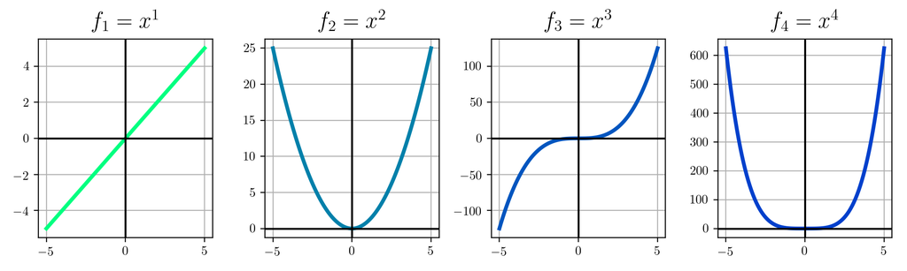

```python
## This code cell will not be shown in the HTML version of this notebook
# build the first 4 non-constant polynomial basis elements
x = np.linspace(-5,5,100)
fig = plt.figure(figsize = (10,3))

for m in range(1,5):
    # make basis element
    fm = x**m
    fm_table = np.stack((x,fm),axis = 1)

    # plot the current element
    ax = fig.add_subplot(1,4,m)
    ax.plot(fm_table[:,0],fm_table[:,1],color = [0,1/float(m),m/float(m+1)],linewidth = 3)
    ax.set_title('$f_'+str(m) + ' = x^' + str(m) + '$',fontsize = 18)

    # clean up plot
    ax.grid(True, which='both')
    ax.axhline(y=0, color='k')
    ax.axvline(x=0, color='k')
plt.show()
```

- With two inputs $x_1$ and $x_2$, a general degree $D$ polynomial unit takes the analogous form below where $p$ and $q$ are non-negative integers and $p + q \leq D$.

\begin{equation} f_b(x_1,x_2) = x_1^px_2^q \label{equation:degree-two-polynomial} \end{equation}

- Classically, a degree $D$ polynomial is a linear combination of all such units. This definition directly generalizes to $N>2$ dimensional input.

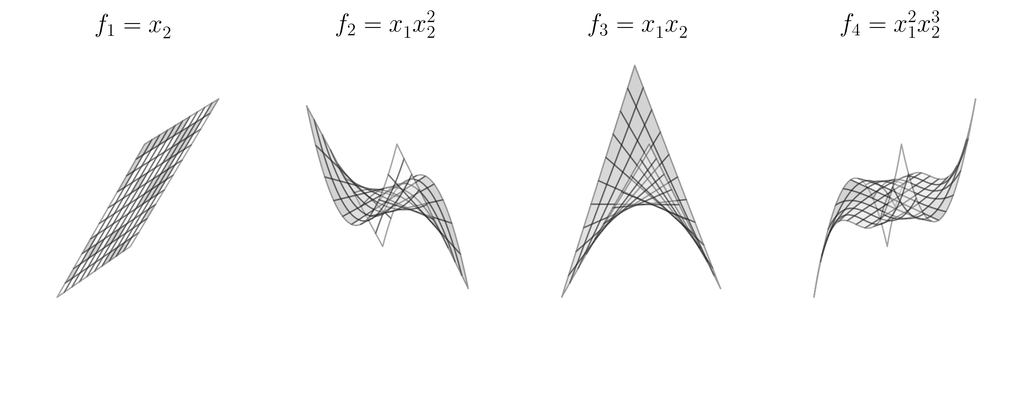

```python
## This code cell will not be shown in the HTML version of this notebook
# generate input values
s = np.linspace(-2,2,100)
x_1,x_2 = np.meshgrid(s,s)
degree_dict = {}

# build 4 polynomial basis elements
fig = plt.figure(num=None, figsize = (10,4), dpi=80, facecolor='w', edgecolor='k')

### plot regression surface ###
p =  [0,1,1,2]
q = [1,2,1,3]
for m in range(4):
    ax1 = plt.subplot(1,4,m+1,projection = '3d')
    ax1.set_axis_off()
    f_m = (x_1**p[m])*(x_2**q[m])
    ax1.plot_surface(x_1,x_2,f_m,alpha = 0.35,color = 'w',zorder = 3,edgecolor = 'k',linewidth=1,cstride = 10, rstride = 10)
    ax1.view_init(20,40)
    deg1 = ''
    if p[m] == 1:
        deg1 = 'x_1^{\,}'
    if p[m] >=2:
        deg1 = 'x_1^' + str(p[m])
    deg2 = ''
    if q[m] == 1:
        deg2 = 'x_2^{\,}'
    if q[m] >=2:
        deg2 = 'x_2^' + str(q[m])
    ax1.set_title('$f_'+str(m+1) + ' = ' + deg1 + deg2 + '$',fontsize = 18)
fig.subplots_adjust(left=0,right=1,bottom=0,top=1)   # remove whitespace around 3d figure
plt.show()
```

#### Example. The neural network family of universal approximators

- The neural networks family consists of *parameterized* functions, allowing them to take on a variety of different shapes (unlike the fixed-shape family).
- The simplest kind of neural networks universal approximator is a parameterized elementary function

\begin{equation} f_1(x) = \text{tanh}\left(w_{1,0} + w_{1,1}x\right), ~~ f_2(x) = \text{tanh}\left(w_{2,0} + w_{2,1}x\right), ~~ \text{etc.} \label{equation:tanh-1-layer-1d} \end{equation}

- Notice the internal parameters $w_{b,0}$ and $w_{b,1}$ of a generic neural network function $f_b(x) = \text{tanh}\left(w_{b,0} + w_{b,1}x\right)$ allow it to take on a variety of shapes, as illustrated below (where these parameters are set randomly).

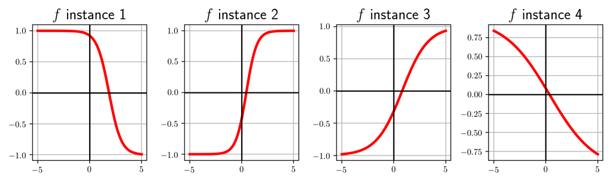

```python
## This code cell will not be shown in the HTML version of this notebook
# build 4 instances of a composition basis: line and tanh
x = np.linspace(-5,5,100)
fig = plt.figure(figsize = (10,3))

for m in range(1,5):
    # make basis element
    w_0 = np.random.randn(1)
    w_1 = np.random.randn(1)
    fm = np.tanh(w_0 + w_1*x)
    fm_table = np.stack((x,fm),axis = 1)

    # plot the current element
    ax = fig.add_subplot(1,4,m)
    ax.plot(fm_table[:,0],fm_table[:,1],c='r',linewidth = 3)
    ax.set_title('$f$ instance ' + str(m),fontsize = 18)

    # clean up plot
    ax.grid(True, which='both')
    ax.axhline(y=0, color='k')
    ax.axvline(x=0, color='k')

plt.show()
```

- To construct neural network features taking in higher dimensional input we take a linear combination of the input and pass the result through the nonlinear function. \begin{equation} f_b\left(\mathbf{x}\right) = \text{tanh}\left(w_{b,0} + w_{b,1}x_1 + \cdots + w_{b,\,N}x_N\right) \label{equation:tanh-1-layer-Nd} \end{equation}
- As with the lower dimensional example, each function above can take on a variety of different shapes, as illustrated below (again with randomly-set parameters).

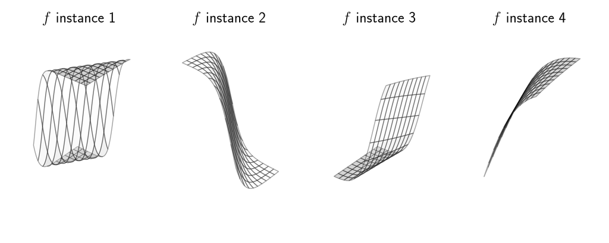

```python
## This code cell will not be shown in the HTML version of this notebook
# generate input values
s = np.linspace(-2,2,100)
x_1,x_2 = np.meshgrid(s,s)
degree_dict = {}

# build 4 polynomial basis elements
fig = plt.figure(num=None, figsize = (10,4), dpi=80, facecolor='w', edgecolor='k')

### plot regression surface ###
p =  [0,1,1,2]
q = [1,2,1,3]
for m in range(4):
    ax1 = plt.subplot(1,4,m+1,projection = '3d')
    ax1.set_axis_off()

    # random weights
    w_0 = np.random.randn(1)
    w_1 = np.random.randn(1)
    w_2 = np.random.randn(1)
    w_3 = np.random.randn(1)
    f_m = w_3*np.tanh(w_0 + w_1*x_1 + w_2*x_2)

    ax1.plot_surface(x_1,x_2,f_m,alpha = 0.35,color = 'w',zorder = 3,edgecolor = 'k',linewidth=1,cstride = 10, rstride = 10)
    ax1.view_init(20,40)
    ax1.set_title('$f$ instance ' + str(m+1),fontsize = 18)

fig.subplots_adjust(left=0,right=1,bottom=0,top=1)   # remove whitespace around 3d figure
plt.show()
```

#### Example. The trees family of universal approximators

- The simplest sort of tree unit consists of discrete step functions or, as they are more commonly referred to, *stumps* whose break lies along a single dimension of the input space.
- A stump with one dimensional input $x$ can be written as follows where $s$ is called a *split point* at which the stump changes values, and $v_{1}$ and $v_{2}$ are values taken by the two sides of the stump respectively, which we refer to as *leaves* of the stump.

\begin{equation} f\left(x\right)=\begin{cases} \begin{array}{c} v_{1}\\ v_{2} \end{array} & \begin{array}{c} x<s\\ x>s \end{array}\end{cases} \label{equation:stump-chapter-11} \end{equation}

- A tree-based universal approximator is a set of such stumps (see figure below).

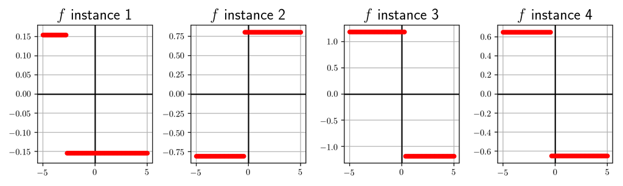

```python
## This code cell will not be shown in the HTML version of this notebook
# build 4 instances of a composition basis: line and tanh
x = np.linspace(-5,5,100)
fig = plt.figure(figsize = (10,3))

for m in range(1,5):
    # make basis element
    w_0 = np.random.randn(1)
    w_1 = np.random.randn(1)
    w_2 = np.random.randn(1)
    fm = w_2*np.sign(w_0 + w_1*x)
    fm_table = np.stack((x,fm),axis = 1)

    # plot the current element
    ax = fig.add_subplot(1,4,m)
    ax.scatter(fm_table[:,0],fm_table[:,1],c='r',s = 20,zorder = 3)
    ax.set_title('$f$ instance ' + str(m),fontsize = 18)

    # clean up plot
    ax.grid(True, which='both')
    ax.axhline(y=0, color='k')
    ax.axvline(x=0, color='k')

plt.show()
```

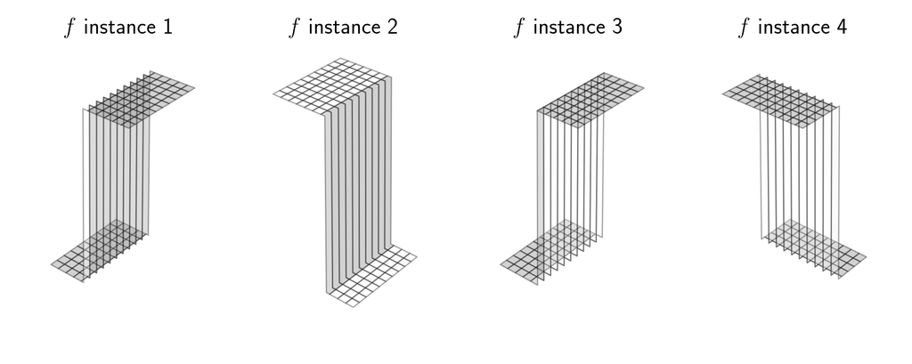

```python
## This code cell will not be shown in the HTML version of this notebook
# generate input values
s = np.linspace(-2,2,100)
x_1,x_2 = np.meshgrid(s,s)
degree_dict = {}

# build 4 polynomial basis elements
fig = plt.figure(num=None, figsize = (10,4), dpi=80, facecolor='w', edgecolor='k')

### plot regression surface ###
for m in range(4):
    ax1 = plt.subplot(1,4,m+1,projection = '3d')
    ax1.set_axis_off()

    # random weights
    r = np.random.randint(2)
    w_0 = 0.1*np.random.randn(1)
    w_1 = np.random.randn(1)*r
    w_2 = np.random.randn(1)*(1 - r)
    w_3 = 3*np.random.randn(1)
    f_m = w_3*np.sign(w_0 + w_1*x_1 + w_2*x_2)

    ax1.plot_surface(x_1,x_2,f_m,alpha = 0.35,color = 'w',zorder = 3,edgecolor = 'k',linewidth=1,cstride = 10, rstride = 10)
    ax1.view_init(20,40)
    ax1.set_title('$f$ instance ' + str(m+1),fontsize = 18)

fig.subplots_adjust(left=0,right=1,bottom=0,top=1)   # remove whitespace around 3d figure
plt.show()
```

## The capacity and optimization dials

$$\text{model}\left(\mathbf{x},\Theta\right) = w_0 + f_1\left(\mathbf{x}\right){w}_{1} + f_2\left(\mathbf{x}\right){w}_{2} + \cdots + f_B\left(\mathbf{x}\right)w_B$$

With any of the major universal approximators (i.e., fixed-shape, neural networks, or trees) we can attain universal approximation to any given precision, provided that the generic nonlinear model above:

1. has sufficiently large *capacity* (e.g., by making $B$ large enough)
2. and that its parameters are tuned sufficiently well through *optimization* of an associated cost function
- The *capacity dial* visually summarizes the amount of capacity we allow into a given model.
- When set all the way to the left we admit as little capacity as possible, i.e., we employ a *linear* model.
- As we move the capacity dial from left to right (clockwise) we adjust the model, adding more and more capacity.

[figure not shown]

- The *optimization dial* visually summarizes how well we minimize the cost function of a given model whose capacity is already set.
- The setting all the way to the left denotes the initial point of whatever local optimization technique we use.
- As we turn the optimization dial from left to right we move further and further along the particular optimization run, with the final step being represented visually as the dial set all the way to the right.

[figure not shown]

#### Example. Linear regression and the two dials

With linear regression we set the capacity dial all the way to the *left* and the optimization dial all the way to the *right* in order to find the best possible set of parameters for a low capacity linear model (drawn in blue) that fits the given regression data.

[figure not shown]

#### Example. Universal function approximation and the two dials

With universal approximation of a continuous function (drawn in black) we set both dials to the *right*, admitting infinite capacity into the model and tuning its parameters by optimizing to completion.

[figure not shown]

#### Example. Universal approximation of near-perfect regression data

In the animation below we illustrate universal approximation of a near-perfect regression dataset consisting of (P = 10,000) evenly sampled points from an underlying sinusoidal function, using

```
- polynomial (left)
- neural network (middle)
- tree units (right)
```

```python
## This code cell will not be shown in the HTML version of this notebook
# produce visual comparison of different universal approximator fits
demo = nonlib.regression_basis_comparison_2d.Visualizer()
csvname = datapath + 'sin_function.csv'
demo.load_data(csvname)
demo.brows_fits(savepath = 'videos/animation_1.mp4',num_elements = [v for v in range(1,71,1)],scatter = 'on',fps=5)

# load in video and display
from IPython.display import HTML
HTML("""
<video width="1000" height="400" controls loop>
  <source src="videos/animation_1.mp4" type="video/mp4">
  </video>
""")
```

[video not shown]

- Note that it takes far fewer units of both the polynomial and neural networks approximators to represent the data well as compared to the discrete stumps.
- This is because members of the former more closely resemble the smooth sinusoidal function that generated the data in the first place.
- This sort of phenomenon is true in general: while any type of universal approximator can be used to approximate a perfect (or near-perfect) dataset as closely as desired, some universal approximators require fewer units to do so than the others depending on the shape of the underlying function that generated the dataset.

#### Example. Universal approximation of near-perfect classification data

[figure not shown]

(top row) Four instances of near-perfect two-class classification data from the perceptron perspective (i.e., from the top). (bottom row) The corresponding datasets shown from the regression perspective (i.e., from the side).

[figure not shown]

The resulting fit from employing $B = 30$ polynomial units using a Least Squares (top row) and softmax cost (bottom row).